# EXST 7151

# Prior for slope ($\beta_1$)

```r
#slope prior (normal)
#would like mean of slope to be 8 (increase inch by 1 unit leads
#to a 8 pound increase, on average, in weight)
mu_B1 = 8 #prior mean
sd_B1 = 5 #prior sd
#Prior function for MCMC
prior_B1 = function(B1,mu_B1,sd_B1){
  dnorm(B1,mu_B1,sd_B1)
}
```

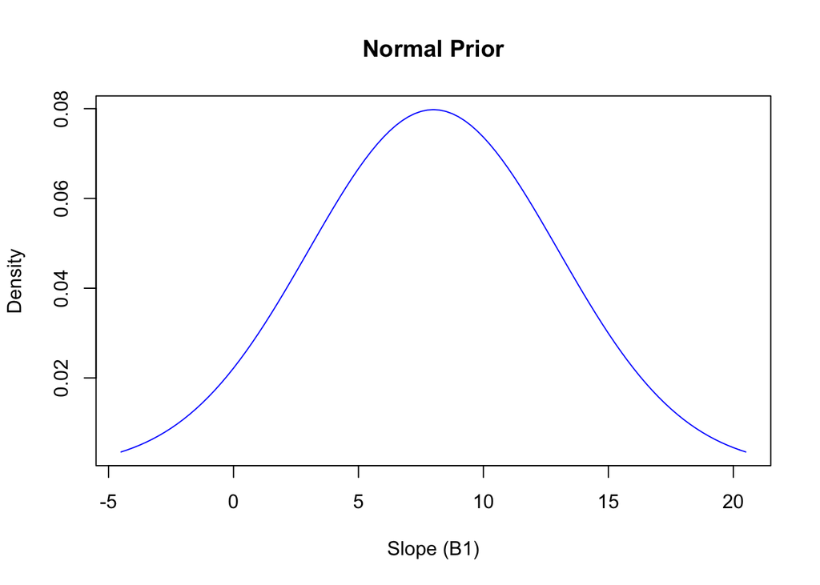

# Prior for variance ($\sigma^2$)

$\sigma^2$ **must** be positive thus a Gamma prior can be appropriate. Although, I have little information outside of this. Choosing a prior with a non-informative prior with a large variance (diffuse prior) seems most reasonable.  
Thus, $\sigma^2$ ~ Gamma(.5,.01).  
E($\sigma^2$) = 50 & Var($\sigma^2$) = 5000

```r
#variance prior (gamma)
shape_var = .5 #prior mean
rate_var = .01 #prior sd
#Prior function for MCMC
prior_var = function(var,shape_var,rate_var){
  dgamma(var,shape=shape_var,rate=rate_var)
}
```

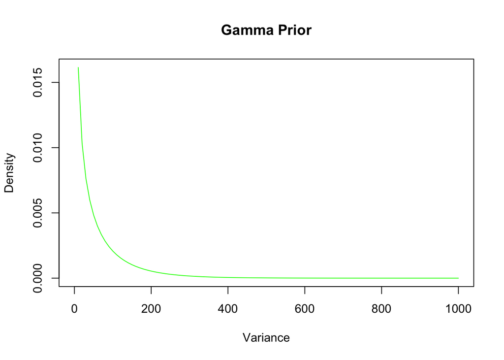

```r
curve(dgamma(x,shape_var,rate=rate_var),xlim = c(0,1000),xlab = "Variance", ylab = "Density", main ="Gamma Prior", col=colors[3])
```

# Liklihood

$y_i$ ~ N($\beta_0$ + $\beta_1$$X_i$, $\sigma^2$)

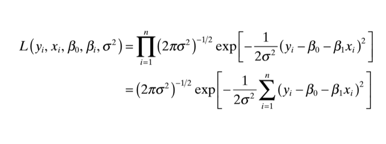

```r
library(png)
library(grid)
img_lik <- readPNG("Liklihood-Function.png")
grid.raster(img_lik)
```

```r
liklihood = function(y,x,theta_B0 ,theta_B1,theta_var){
  sum(dnorm(y,theta_B0+theta_B1*x,sqrt(theta_var)))
}
```

# Prior Predictive Check

Using a prior predictive check is one way to examine what our model believes **before** it has seen any data. I sampled an intercept and slope randomly from each respective prior distribution and plotted the lines.

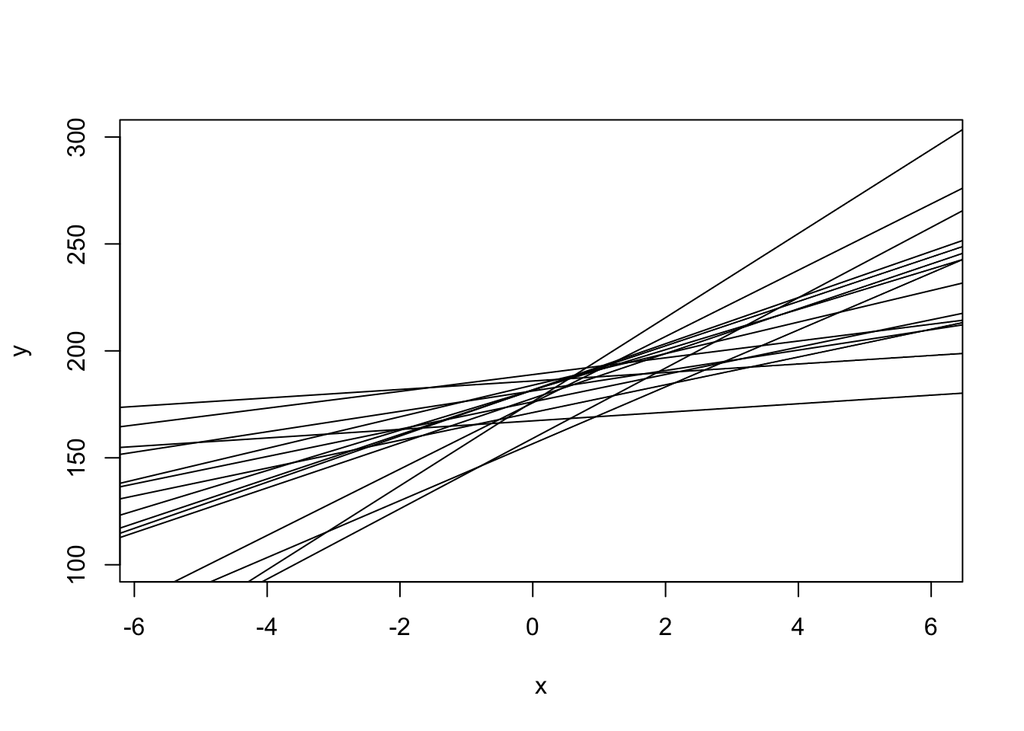

```r
#prior predictive check
intercept = c()
slope = c()
plot(y~x,cex=0.0001, ylim=c(100,300))
for (i in 1:15) {
  intercept[i] = rgamma(1,shape=shape_B0,rate=rate_B0)
  slope[i] = rnorm(1,mean=mu_B1,sd=sd_B1)
  abline(a=intercept[i],b=slope[i],col="black")
}
```

The prior predictive check yields lines that appear **reasonable** given our prior knowledge about the world. While we can only examine the plausibility of our prior for 2 of 3 parameters (interept & slope) using a prior predictive check, it is still a useful exercise.